# Pfizer ve BioNTech Aşı Tweetleri Metin Analizi

Sevdanur GENC

**Pfizer** ve **BioNTech** tarafından işbirliği içinde yapılan aşı hakkında güncel tweetler metin madenciliği yöntemleriyle analiz edilerek ve uygun görselleştirmeler yapılarak anlatılmaktadır.

##Gerekli Kütüphaneler

```r
library(tm)           #metin madenciligi
library(wordcloud)    #kelime bulutu oluşturmak
library(wordcloud2)   #farklı tarzda bir kelime bulutu oluşturmak
library(RColorBrewer) #renk paleti
library(tidytext)     #metin bloklarını parçalayıp sıklıkla kullanılan ifadelere ulaşmak
library(tidyverse)    #dplyr, ggplot2, tidyr
library(ggplot2)      #görselleştirme
library(data.table)
library(rJava)
library(qdap)    #en fazla kullanılan kelimeler
library(RWeka)   #kelime grupları yaratmak
library(ggthemes) #korelasyon grafiği oluşturma
#Duygu analizi
library(syuzhet)
library(lubridate)
library(scales)
library(reshape2)
library(textdata)
library(janeaustenr)
library(stringr)
library(plyr)
library(RSentiment)
```

## Veri Seti Hakkında Bilgi ve Veri Setinin Yüklenmesi

```r
vaccination <- read_csv("C:/Users/Nano/Desktop/MLAlgo/Sample-02/vaccination_tweets_new.csv")
```

```r
View(vaccination)
max(vaccination$date)
```

```
## [1] "2021-01-13 07:29:30 UTC"
```

```r
min(vaccination$date)
```

```
## [1] "2020-12-12 11:55:28 UTC"
```

Veri seti, 2019 yılında tüm dünyada ortaya çıkan koronavirüs(covid-19) ile mücadelede **Pfizer** ve **BioNTech** tarafından işbirliği içinde yapılan *12/12/2020 - 01/13/2021* arası aşı hakkındaki tweetleri içermektedir.

Veri seti kaynağı:https://www.kaggle.com/gpreda/pfizer-vaccine-tweets

##Veri Setinin Özellikleri

```r
summary(vaccination)  #veriseti özeti
```

```
##        id             user_name         user_location      user_description
##  Min.   :1.338e+18   Length:3302        Length:3302        Length:3302
##  1st Qu.:1.340e+18   Class :character   Class :character   Class :character
##  Median :1.343e+18   Mode  :character   Mode  :character   Mode  :character
##  Mean   :1.343e+18
##  3rd Qu.:1.347e+18
##  Max.   :1.349e+18
##   user_created                   user_followers      user_friends
##  Min.   :2006-07-15 21:06:00.0   Min.   :       0   Min.   :    0.0
##  1st Qu.:2010-06-20 16:38:45.0   1st Qu.:     114   1st Qu.:  165.0
##  Median :2013-08-02 19:42:58.0   Median :     508   Median :  459.5
##  Mean   :2014-04-20 12:20:01.4   Mean   :   51407   Mean   : 1157.5
##  3rd Qu.:2018-06-02 09:44:11.0   3rd Qu.:    2384   3rd Qu.: 1197.0
##  Max.   :2021-01-11 22:22:10.0   Max.   :13714928   Max.   :64441.0
##  user_favourites    user_verified        date
##  Min.   :     0.0   Mode :logical   Min.   :2020-12-12 11:55:28.00
##  1st Qu.:   377.2   FALSE:2896      1st Qu.:2020-12-18 20:04:24.25
##  Median :  1770.0   TRUE :406       Median :2020-12-27 19:26:06.00
##  Mean   : 14275.7                   Mean   :2020-12-28 03:48:13.98
##  3rd Qu.: 10307.0                   3rd Qu.:2021-01-06 16:58:57.25
##  Max.   :924667.0                   Max.   :2021-01-13 07:29:30.00
##      text             hashtags            source             retweets
##  Length:3302        Length:3302        Length:3302        Min.   :  0.000
##  Class :character   Class :character   Class :character   1st Qu.:  0.000
##  Mode  :character   Mode  :character   Mode  :character   Median :  0.000
##                                                           Mean   :  1.678
##                                                           3rd Qu.:  1.000
##                                                           Max.   :446.000
##    favorites      is_retweet
##  Min.   :   0.0   Mode :logical
##  1st Qu.:   0.0   FALSE:3302
##  Median :   1.0
##  Mean   :  11.2
##  3rd Qu.:   5.0
##  Max.   :2129.0
```

```r
head(vaccination)  #ilk 6 satır
```

```
## # A tibble: 6 × 16
##        id user_name  user_…¹ user_…² user_created        user_…³ user_…⁴ user_…⁵
##     <dbl> <chr>      <chr>   <chr>   <dttm>                <dbl>   <dbl>   <dbl>
## 1 1.34e18 "Rachel R… La Cre… "Aggre… 2009-04-08 17:52:46     405    1692    3247
## 2 1.34e18 "Albert F… San Fr… "Marke… 2009-09-21 15:27:30     834     666     178
## 3 1.34e18 "eli\U000… Your B… "heil,… 2020-06-25 23:30:28      10      88     155
## 4 1.34e18 "Charles … Vancou… "Hosti… 2008-09-10 11:28:53   49165    3933   21853
## 5 1.34e18 "Citizen … <NA>    "Citiz… 2020-04-23 17:58:42     152     580    1473
## 6 1.34e18 "Dee"      Birmin… "Gastr… 2020-01-26 21:43:12     105     108     106
## # … with 8 more variables: user_verified <lgl>, date <dttm>, text <chr>,
## #   hashtags <chr>, source <chr>, retweets <dbl>, favorites <dbl>,
## #   is_retweet <lgl>, and abbreviated variable names ¹user_location,
## #   ²user_description, ³user_followers, ⁴user_friends, ⁵user_favourites
```

Veri seti 16 değişkenden oluşmaktadır. 3302 adet metin parçası bulunmaktadır.

```r
glimpse(vaccination)
```

```
## Rows: 3,302
## Columns: 16
## $ id               <dbl> 1.340539e+18, 1.338159e+18, 1.337858e+18, 1.337856e+1…
## $ user_name        <chr> "Rachel Roh", "Albert Fong", "eli🇱🇹🇪🇺👌", "Charles Ad…
## $ user_location    <chr> "La Crescenta-Montrose, CA", "San Francisco, CA", "Yo…
## $ user_description <chr> "Aggregator of Asian American news; scanning diverse …
## $ user_created     <dttm> 2009-04-08 17:52:46, 2009-09-21 15:27:30, 2020-06-25…
## $ user_followers   <dbl> 405, 834, 10, 49165, 152, 105, 2731, 21924, 887, 671,…
## $ user_friends     <dbl> 1692, 666, 88, 3933, 580, 108, 5001, 593, 1515, 2368,…
## $ user_favourites  <dbl> 3247, 178, 155, 21853, 1473, 106, 69344, 7815, 9639, …
## $ user_verified    <lgl> FALSE, FALSE, FALSE, TRUE, FALSE, FALSE, FALSE, TRUE,…
## $ date             <dttm> 2020-12-20 06:06:44, 2020-12-13 16:27:13, 2020-12-12…
## $ text             <chr> "Same folks said daikon paste could treat a cytokine …
## $ hashtags         <chr> "['PfizerBioNTech']", NA, "['coronavirus', 'SputnikV'…
## $ source           <chr> "Twitter for Android", "Twitter Web App", "Twitter fo…
## $ retweets         <dbl> 0, 1, 0, 446, 0, 0, 0, 2, 2, 0, 0, 0, 0, 48, 0, 0, 2,…
## $ favorites        <dbl> 0, 1, 0, 2129, 0, 0, 4, 22, 1, 0, 0, 0, 18, 82, 0, 1,…
## $ is_retweet       <lgl> FALSE, FALSE, FALSE, FALSE, FALSE, FALSE, FALSE, FALS…
```

Görüldüğü gibi vaccination veri tabanında istenilen metin dışında diğer değişkenler de bulunuyor. Öncelikli olarak, “text” sütunu altında toplanmış metin kısmını bu veri tabanından bir vektör halinde ayrıştırılır.

```r
asi.tweet <- vaccination$text
```

## Corpus (Yapı) Oluşturma

Bu metnin analizinde **Corpus** adı verilen yapıyı oluşturmak için **tm()** paketinin **VectorSource()** ve **VCorpus()** fonksiyonları kullanılır.

```r
asi.kaynak <- VectorSource(asi.tweet)
asi.corpus <- VCorpus(asi.kaynak)
```

**VCorpus** nesnesi bir iç içe geçmiş listeler olarak düşünülebilir. Corpustaki 20. tweete bakılırsa;

```r
#ası.corpus'u çağıralım
asi.corpus
```

```
## <<VCorpus>>
## Metadata:  corpus specific: 0, document level (indexed): 0
## Content:  documents: 3302
```

```r
#ası.corpus içindeki 20. tweet
asi.corpus[[20]]
```

```
## <<PlainTextDocument>>
## Metadata:  7
## Content:  chars: 136
```

```r
#ası.corpus içindeki 20. tweetin metni
asi.corpus[[20]][1]
```

```
## $content
## [1] "The trump administration failed to deliver on vaccine promises, *shocker* #COVIDIOTS #coronavirus #CovidVaccine… https://t.co/hew6eHTUrD"
```

## Veri Temizleme

```r
asi.urlsiz <- function(x) gsub("https://t.co/[A-Za-z\\d]+|&amp;"," ",x)
asi.ing <- function(x) gsub("[^[:alpha:][:space:]]*","",x)

asi.tweettidy <- function(corpus){
  corpus <- tm_map(asi.corpus,PlainTextDocument)
  corpus <- tm_map(corpus, content_transformer(asi.urlsiz ))
  corpus <- tm_map(corpus, stripWhitespace)
  corpus <- tm_map(corpus, removePunctuation)
  corpus <- tm_map(corpus, content_transformer(tolower))
  corpus <- tm_map(corpus, removeWords, stopwords::stopwords("en", source = "stopwords-iso"))
  corpus <- tm_map(corpus, content_transformer(asi.ing))
  return(corpus)
}

asi.tweet.tidy<-asi.tweettidy(asi.corpus)
asi.tweet.tidy[[50]][1]    #temizlenmiş 50.tweet
```

```
## $content
## [1] "covid news  updates public questioned    received  shot video footage appeared   pjbl"
```

```r
vaccination$text[50]       #temizlemeden önceki 50.tweet
```

```
## [1] "COVID-19: News and updates\npublic questioned whether he actually received the shot.\nVideo footage appeared to show… https://t.co/lBc2PJ2b9l"
```

Kelime sıklık matrisi oluşturulduktan sonra sıralı bir şekilde ilk 10 kelime data frame (veri çerçevesi) formatına getirilir.

```r
asi.tdm <- TermDocumentMatrix(asi.tweet.tidy)
asi.m <- as.matrix(asi.tdm)
asi.v <- sort(rowSums(asi.m),decreasing=TRUE)
asi.df <- data.frame(word = names(asi.v),freq=asi.v)
head(asi.df, 10)
```

```
##                          word freq
## pfizerbiontech pfizerbiontech 1794
## vaccine               vaccine 1505
## covid                   covid 1103
## pfizer                 pfizer  396
## covidvaccine     covidvaccine  359
## dose                     dose  322
## vaccines             vaccines  228
## coronavirus       coronavirus  225
## vaccination       vaccination  187
## pfizervaccine   pfizervaccine  150
```

Yukarıdaki fonksiyonlarının çalıştırılmasıyla elde edilen sıklık çerçeve tablosu yukarıda görüldüğü gibidir. Tabloda da görüldüğü üzere en sık kullanılan kelime aşının ismi **pfizerbiontech** tir. Daha sonra sırasıyla **vaccine** ve **covid** kelimeleri gelmektedir.

Kelime Köklerinin Bulunması

```r
text_data <- asi.tweet
#Noktalama isaretlerini kaldirma
rm_punc <- removePunctuation(text_data)
#Karakter vektoru olusturma
n_char_vec <- unlist(strsplit(rm_punc, split = ' '))
#Kelime turetme islemi
stem_doc <- stemDocument(n_char_vec)
head(stem_doc,50)
```

```
##  [1] "Same"               "folk"               "said"
##  [4] "daikon"             "past"               "could"
##  [7] "treat"              "a"                  "cytokin"
## [10] "storm"              "PfizerBioNTech"     "httpstcoxeHhIMg1kF"
## [13] "While"              "the"                "world"
## [16] "has"                "been"               "on"
## [19] "the"                "wrong"              "side"
## [22] "of"                 "histori"            "this"
## [25] "year"               "hope"               "the"
## [28] "biggest"            "vaccin"             "effort"
## [31] "weve"               "ev…"                "httpstcodlCHrZjkhm"
## [34] "coronavirus"        "SputnikV"           "AstraZeneca"
## [37] "PfizerBioNTech"     "Moderna"            "Covid19"
## [40] "Russian"            "vaccin"             "is"
## [43] "creat"              "to"                 "last"
## [46] "24"                 "years…"             "httpstcoieYlCKBr8P"
## [49] "Fact"               "are"
```

Sık kullanılan kelimelerin grafikleri çizdirilirse;

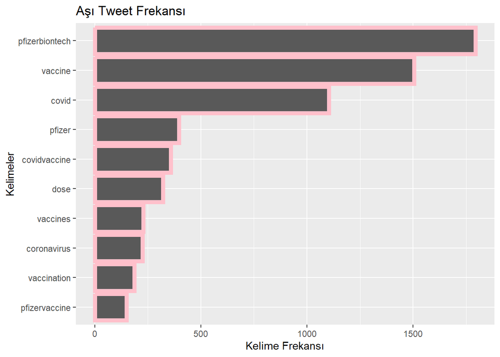

```r
#Sütun grafiği
ggplot(head(asi.df,10), aes(reorder(word,freq), freq)) +
  geom_bar(stat = "identity",col="pink",size=2) + coord_flip() +
  xlab("Kelimeler") + ylab("Kelime Frekansı") +
  ggtitle("Aşı Tweet Frekansı")
```

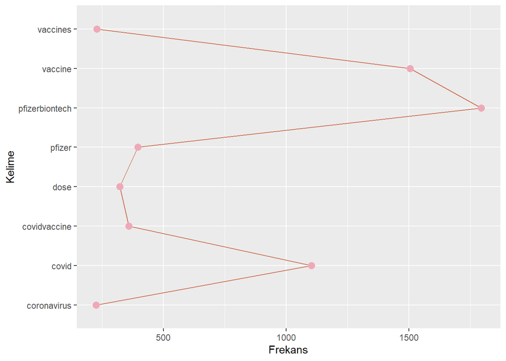

```r
asi.frekans <- subset(asi.v,asi.v >= 200)
asi.frekans.df <- data.frame(term = names(asi.frekans), freqs = asi.frekans)
ggplot(asi.frekans.df, aes(x=term, y=freqs)) +
  geom_line(aes(group=1),colour="salmon3") + geom_point(size=3, colour="pink2")+
  xlab("Kelime")+ylab("Frekans") + coord_flip()
```

Kelime bulutu oluşturarak süreç tamamlanır. Bu aşamada her defasında aynı sonuçların ve düzenin elde edilebilmesi için **set.seed()** ve random.order=FALSE fonksiyonları kullanılır. Kelimeleri renklerdirmek için **brewer.pal()** fonksiyonu kullanılır.

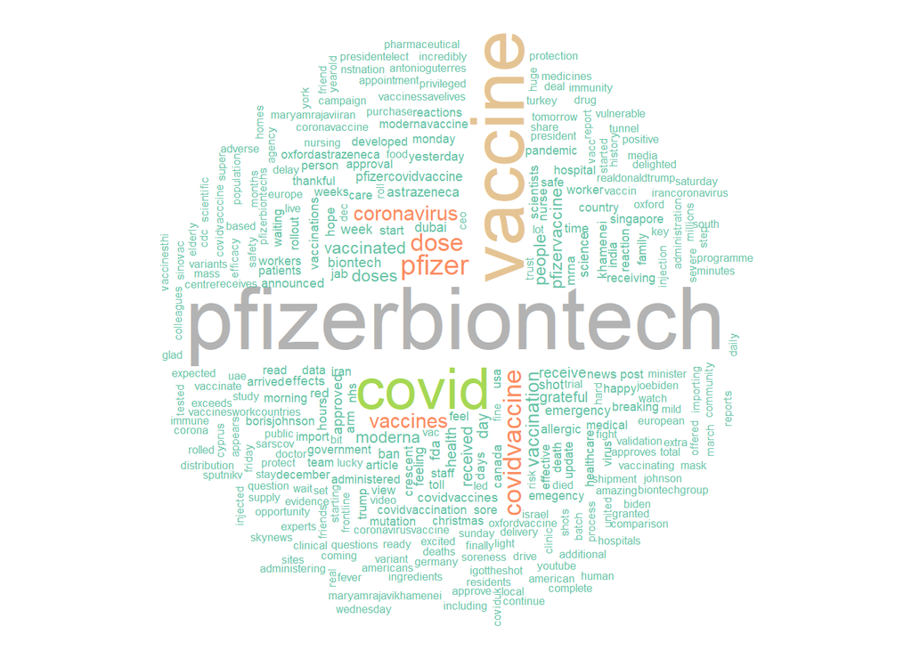

```r
set.seed(1234)

wordcloud(words = asi.df$word, freq = asi.df$freq, min.freq = 2,
          max.words=300, random.order=FALSE, rot.per=0.35,
          colors=brewer.pal(8, "Set2"))
```

Kelime bulutumuzu wordcloud2 paketini kullanarakta farklı bir bulut oluşturabiliriz.

```r
wordcloud2(asi.df, size=1.6, color='random-light', backgroundColor="black")
```

[interactive chart not shown]

Yukarıda oluşturulan tablo grafikle de gösterilebilir.

```r
library(ggplot2)
str(asi.df)
```

```
## 'data.frame':    8665 obs. of  2 variables:
##  $ word: chr  "pfizerbiontech" "vaccine" "covid" "pfizer" ...
##  $ freq: num  1794 1505 1103 396 359 ...
```

```r
y<-head(asi.df, 10)
y
```

```
##                          word freq
## pfizerbiontech pfizerbiontech 1794
## vaccine               vaccine 1505
## covid                   covid 1103
## pfizer                 pfizer  396
## covidvaccine     covidvaccine  359
## dose                     dose  322
## vaccines             vaccines  228
## coronavirus       coronavirus  225
## vaccination       vaccination  187
## pfizervaccine   pfizervaccine  150
```

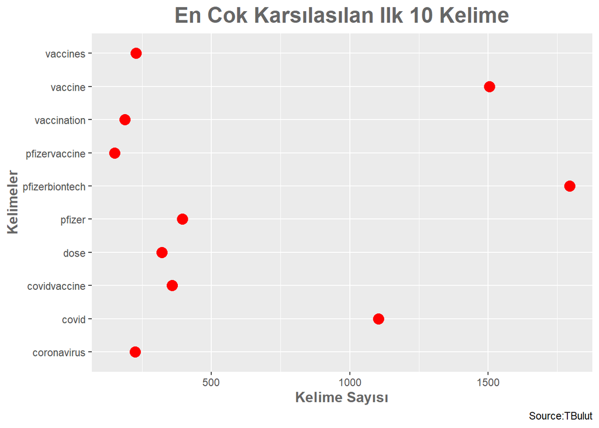

```r
ggplot(y)+geom_point(aes(freq, word),col="red",size=4)+
labs(subtitle=NULL, y="Kelimeler", x="Kelime Sayısı",title="En Cok Karsılasılan Ilk 10 Kelime", caption = "Source:TBulut")+
  theme(plot.title = element_text(family = "Trebuchet MS", color="#666666", face="bold", size=18, hjust=0.5)) +
theme(axis.title = element_text(family = "Trebuchet MS", color="#666666", face="bold", size=12))
```

## Dendogram ve Korelasyon

```r
#asi.tdm nin boyutları
dim(asi.tdm)
```

```
## [1] 8665 3302
```

```r
#Birinci seyrekleştirme işlemi
asi.tdm1 <- removeSparseTerms(asi.tdm, sparse = 0.95)

#İkinici seyrekleştirme işlemi
asi.tdm2 <- removeSparseTerms(asi.tdm, sparse = 0.98)

#Print tdm1
asi.tdm1
```

```
## <<TermDocumentMatrix (terms: 9, documents: 3302)>>
## Non-/sparse entries: 5844/23874
## Sparsity           : 80%
## Maximal term length: 14
## Weighting          : term frequency (tf)
```

```r
#Print tdm2
asi.tdm2
```

```
## <<TermDocumentMatrix (terms: 23, documents: 3302)>>
## Non-/sparse entries: 7345/68601
## Sparsity           : 90%
## Maximal term length: 18
## Weighting          : term frequency (tf)
```

Dendogramı oluşturmak için kullanacağımız **dist()** fonksiyonu için ilk başta TDM’yi önce bir matris haline ve takiben bir veri tabanı haline çevrilmesi gerekir.

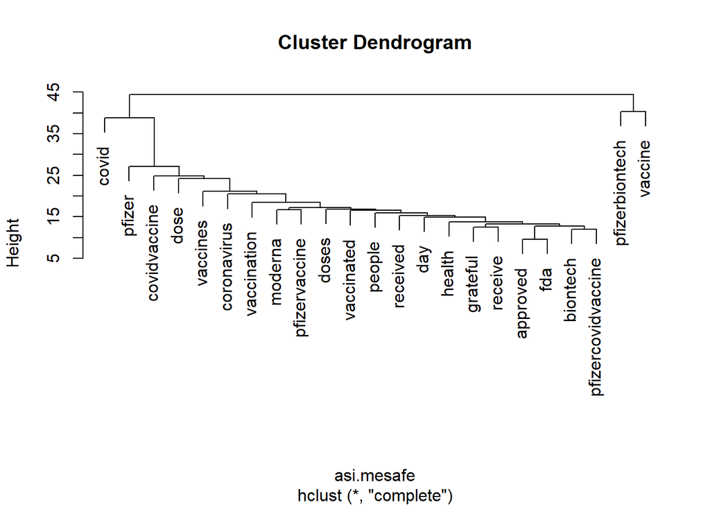

```r
#matrisi oluşturma
asi.tdm.m <- as.matrix(asi.tdm2)

#veri tabanı oluşturma
asi.tdm.vt <- as.data.frame(asi.tdm.m)

#kelimeler arası mesafeler
asi.mesafe <- dist(asi.tdm.vt)

#Kümeleme işlemi
asi.kume <- hclust(asi.mesafe)

#Dendogram çizimi
plot(asi.kume)
```

Kelimeler arasındaki ilişkiyi görselleştirmek için bir diğer yol ise korelasyon grafiğidir.

```r
#Korelasyonları hesaplayalım
korelasyonlar <- findAssocs(asi.tdm, "coronavirus", 0.2);korelasyonlar
```

```
## $coronavirus
## emegency     view    rises  article      fda approved
##     0.33     0.32     0.26     0.25     0.24     0.22
```

```r
#korelasyonları veri tabanı haline çevirelim
korelasyonlar.df <- list_vect2df(korelasyonlar)[, 2:3];korelasyonlar.df
```

```
##         X2   X3
## 1 approved 0.22
## 2      fda 0.24
## 3  article 0.25
## 4    rises 0.26
## 5     view 0.32
## 6 emegency 0.33
```

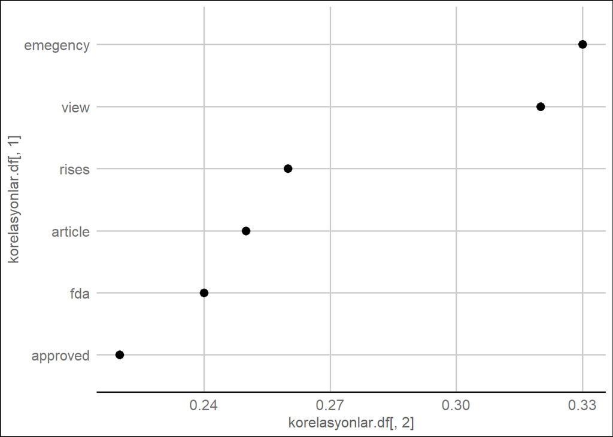

```r
#grafikleyelim
ggplot(korelasyonlar.df, aes(y = korelasyonlar.df [, 1])) +
  geom_point(aes(x = korelasyonlar.df [, 2]),
             data = korelasyonlar.df , size = 3) +
   theme_gdocs()
```

Düzenlediğimiz veri üzerinden ikili kelime grupları oluşturulur.

Kelime grupları oluşturmak için RWeka paketi kullanılır.

```r
bigram.tokenizer = function(x) NGramTokenizer(x, Weka_control(min = 2, max = 2))
tdm.bigram = TermDocumentMatrix(asi.tweet.tidy,control = list(tokenize = bigram.tokenizer))
freq2 = sort(rowSums(as.matrix(tdm.bigram)),decreasing = TRUE)

asi.df2 = data.frame(word=names(freq2), freq=freq2)
head(asi.df2, 10)
```

```
##                                                    word freq
## covid vaccine                             covid vaccine  451
## pfizerbiontech vaccine           pfizerbiontech vaccine  407
## pfizerbiontech covid               pfizerbiontech covid  197
## dose pfizerbiontech                 dose pfizerbiontech  116
## pfizerbiontech covidvaccine pfizerbiontech covidvaccine  116
## coronavirus vaccine                 coronavirus vaccine   83
## covid pfizerbiontech               covid pfizerbiontech   70
## covidvaccine pfizerbiontech covidvaccine pfizerbiontech   67
## vaccine pfizerbiontech           vaccine pfizerbiontech   65
## pfizer vaccine                           pfizer vaccine   64
```

Sık kullanılan ikili kelime gruplarının sütun grafiği çizdirilir.

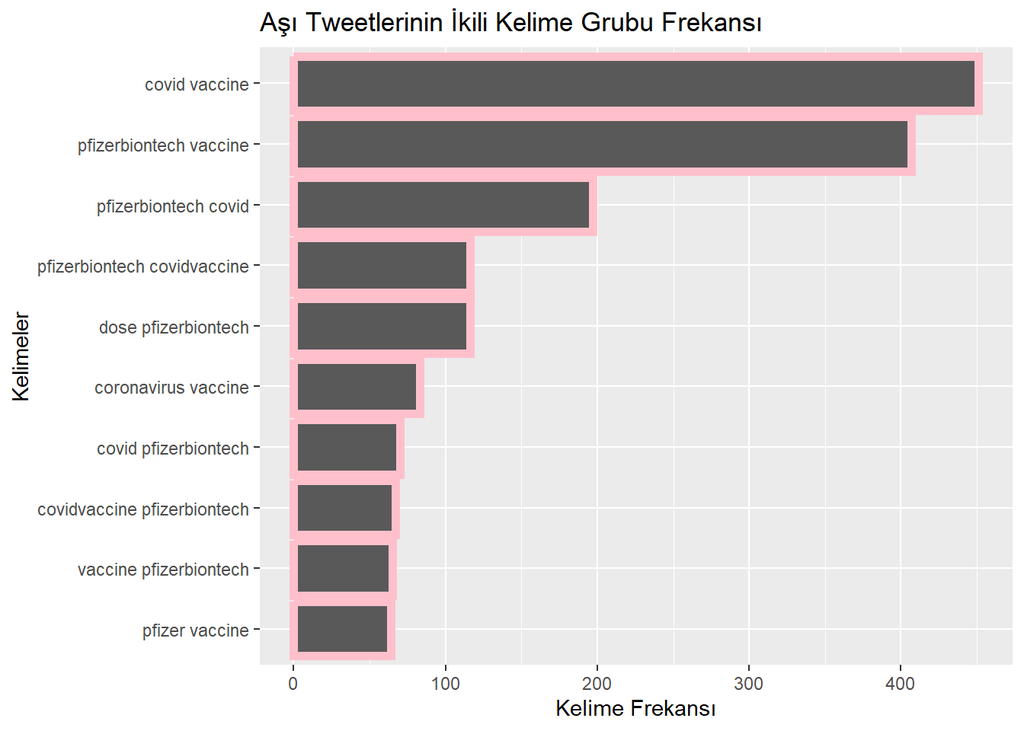

```r
#Sütun grafiği
ggplot(head(asi.df2,10), aes(reorder(word,freq), freq)) +
  geom_bar(stat = "identity",col="pink",size=2) + coord_flip() +
  xlab("Kelimeler") + ylab("Kelime Frekansı") +
  ggtitle("Aşı Tweetlerinin İkili Kelime Grubu Frekansı")
```

Grafikte **covid vaccine** kelime grubunun daha sık kullanıldığı görülmektedir.

İkili kelime gruplarının kelime bulutları oluşturulur.

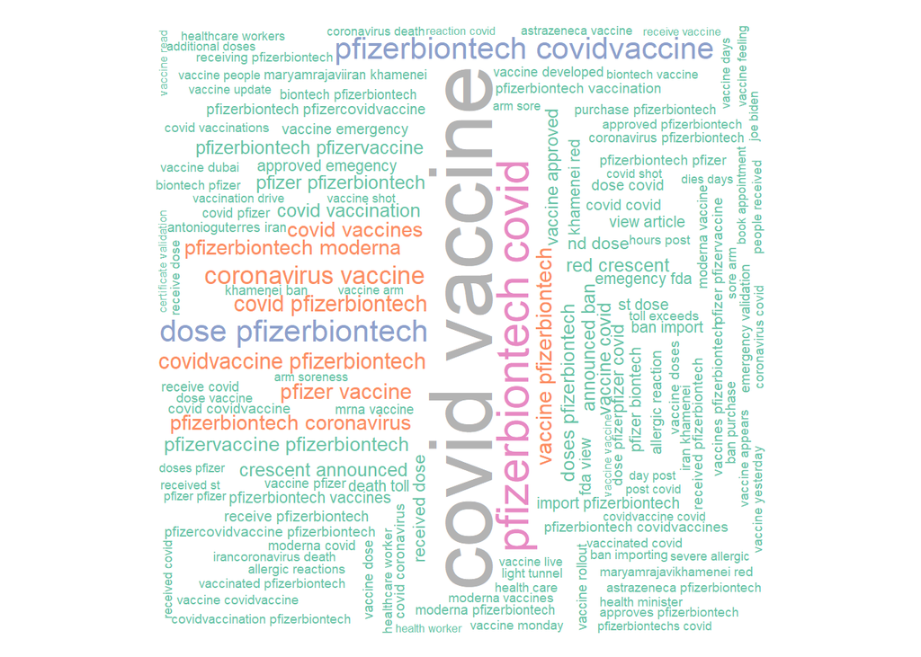

```r
set.seed(1234)

wordcloud(words = asi.df2$word, freq = asi.df2$freq, min.freq = 2,
          max.words=200, random.order=FALSE, rot.per=0.35,
          colors=brewer.pal(8, "Set2"))
```

Üçlü kelime grubu oluşturulur.

```r
trigram.tokenizer <- function(x) NGramTokenizer(x, Weka_control(min = 3, max = 3))
tdm.trigram = TermDocumentMatrix(asi.tweet.tidy,control = list(tokenize = trigram.tokenizer))
freq3= sort(rowSums(as.matrix(tdm.trigram)),decreasing = TRUE)
asi.df3 = data.frame(word=names(freq3), freq=freq3)
head(asi.df3,10)
```

```
##                                                                  word freq
## pfizerbiontech covid vaccine             pfizerbiontech covid vaccine  151
## pfizerbiontech coronavirus vaccine pfizerbiontech coronavirus vaccine   53
## dose pfizerbiontech vaccine               dose pfizerbiontech vaccine   45
## crescent announced ban                         crescent announced ban   44
## red crescent announced                         red crescent announced   44
## pfizer covid vaccine                             pfizer covid vaccine   34
## coronavirus vaccine approved             coronavirus vaccine approved   30
## khamenei red crescent                           khamenei red crescent   30
## announced ban import                             announced ban import   29
## approved emegency fda                           approved emegency fda   29
```

Üçlü kelime gruplarının sütun grafiği oluşturulur.

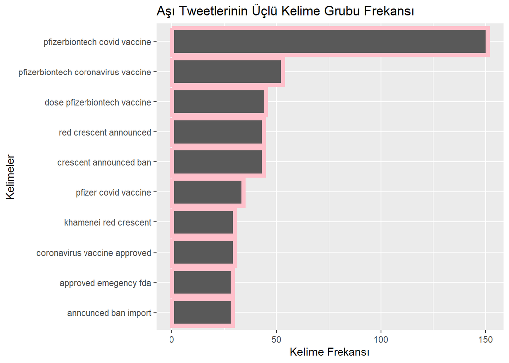

```r
#Sütun grafiği
ggplot(head(asi.df3,10), aes(reorder(word,freq), freq)) +
  geom_bar(stat = "identity",col="pink",size=2) + coord_flip() +
  xlab("Kelimeler") + ylab("Kelime Frekansı") +
  ggtitle("Aşı Tweetlerinin Üçlü Kelime Grubu Frekansı")
```

Grafikte **pfizerbiontech covid vaccine** kelime grubunun daha sık kullanıldığı görülmektedir.

Üçlü kelime grubunun kelime bulutu oluşturulur.

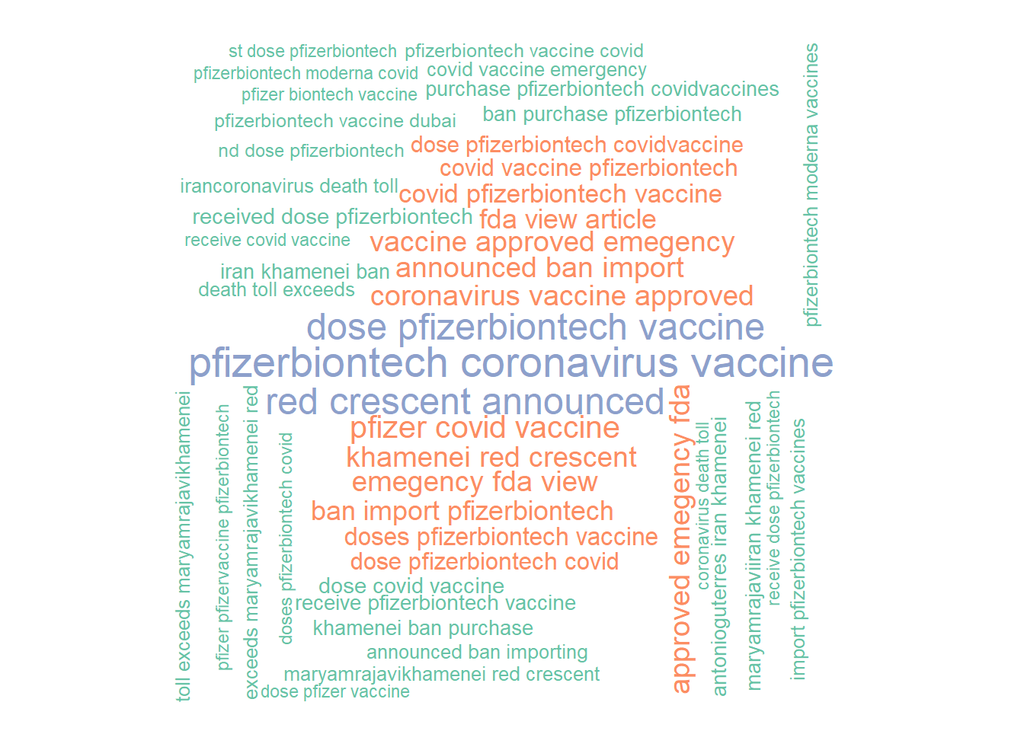

```r
set.seed(1234)

wordcloud(words = asi.df3$word, freq = asi.df3$freq, min.freq = 2,
          max.words=50, random.order=FALSE, rot.per=0.35,
          colors=brewer.pal(8, "Set2"))
```

## Duygu Analizi

```r
asi.da <- iconv(vaccination)
da <- get_nrc_sentiment(asi.da)
head(da)
```

```
##   anger anticipation disgust fear joy sadness surprise trust negative positive
## 1     0            0       0    0   0       0        0     0        0        0
## 2    33           41      23   37  37      29       15    80       52      114
## 3     4           14       2    4  12       6        8    23       10       36
## 4   149          229     112  198 212     161      101   405      366      643
## 5     0            0       0    0   0       0        0     0        0        0
## 6     0            0       0    0   0       0        0     0        0        0
```

```r
get_nrc_sentiment('delay')
```

```
##   anger anticipation disgust fear joy sadness surprise trust negative positive
## 1     1            0       1    1   0       1        0     0        1        0
```

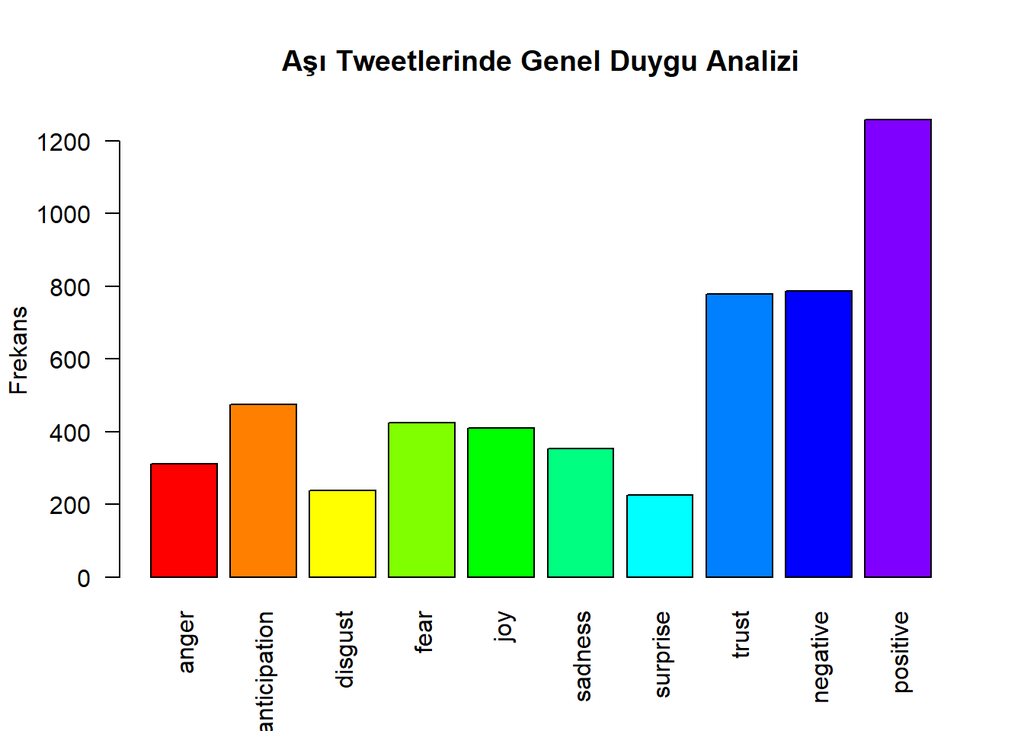

```r
barplot(colSums(da),
        las = 2,
        col = rainbow(12),
        ylab = 'Frekans',
        main = 'Aşı Tweetlerinde Genel Duygu Analizi')
```

Aşı hakkında atılan genel tweetlere baktığımızda sıklıkla **pozitif** düşünceleri gördüğümüz gibi, **negatif** düsünceleri de görmekteyiz.

## Belirli Ülkeler Arası Aşı Tweetleri Duygu Analizi

```r
removeNA.data=na.omit(vaccination)
USA=removeNA.data[str_detect(removeNA.data$user_location, "USA"), ]
TURKEY=removeNA.data[str_detect(removeNA.data$user_location, "Türkiye"), ]
GERMANY=removeNA.data[str_detect(removeNA.data$user_location, "Germany"), ]
ITALY=removeNA.data[str_detect(removeNA.data$user_location, "Italy"), ]

par(mfrow=c(2,2))

USA.D <- iconv(USA)
USA.DA <- get_nrc_sentiment(USA.D)
head(USA.DA)
```

```
##   anger anticipation disgust fear joy sadness surprise trust negative positive
## 1     0            0       0    0   0       0        0     0        0        0
## 2     1            4       1    2   4       1        3     6        3        5
## 3     0            0       0    0   0       0        1     0        0        0
## 4    11           30      13   19  29      16       13    67       35       80
## 5     0            0       0    0   0       0        0     0        0        0
## 6     0            0       0    0   0       0        0     0        0        0
```

```r
get_nrc_sentiment('delay')
```

```
##   anger anticipation disgust fear joy sadness surprise trust negative positive
## 1     1            0       1    1   0       1        0     0        1        0
```

```r
barplot(colSums(USA.DA),
        las = 2,
        col = rainbow(12),
        ylab = 'Frekans',
        main = 'Aşı Tweetleri Amerika Duygu Analizi')

TURKEY.D <- iconv(TURKEY)
TURKEY.DA <- get_nrc_sentiment(TURKEY.D)
head(TURKEY.DA)
```

```
##   anger anticipation disgust fear joy sadness surprise trust negative positive
## 1     0            0       0    0   0       0        0     0        0        0
## 2     0            0       0    0   0       0        0     0        0        0
## 3     0            0       0    0   0       0        0     0        0        0
## 4     0            0       0    0   0       0        0     2        0        0
## 5     0            0       0    0   0       0        0     0        0        0
## 6     0            0       0    0   0       0        0     0        0        0
```

```r
get_nrc_sentiment('delay')
```

```
##   anger anticipation disgust fear joy sadness surprise trust negative positive
## 1     1            0       1    1   0       1        0     0        1        0
```

```r
barplot(colSums(TURKEY.DA),
        las = 2,
        col = rainbow(12),
        ylab = 'Frekans',
        main = 'Aşı Tweetleri Türkiye Duygu Analizi')

GERMANY.D <- iconv(GERMANY)
GERMANY.DA <- get_nrc_sentiment(GERMANY.D)
head(GERMANY.DA)
```

```
##   anger anticipation disgust fear joy sadness surprise trust negative positive
## 1     0            0       0    0   0       0        0     0        0        0
## 2     1            1       0    0   0       0        0     0        1        0
## 3     0            0       0    0   0       0        0     0        0        0
## 4     2            7       2    1   6       1        1    15        4       18
## 5     0            0       0    0   0       0        0     0        0        0
## 6     0            0       0    0   0       0        0     0        0        0
```

```r
get_nrc_sentiment('delay')
```

```
##   anger anticipation disgust fear joy sadness surprise trust negative positive
## 1     1            0       1    1   0       1        0     0        1        0
```

```r
barplot(colSums(GERMANY.DA),
        las = 2,
        col = rainbow(12),
        ylab = 'Frekans',
        main = 'Aşı Tweetleri Almanya Duygu Analizi')

ITALY.D<- iconv(ITALY)
ITALY.DA <- get_nrc_sentiment(ITALY.D)
head(ITALY.DA)
```

```
##   anger anticipation disgust fear joy sadness surprise trust negative positive
## 1     0            0       0    0   0       0        0     0        0        0
## 2     0            0       0    0   0       0        0     0        0        0
## 3     0            0       0    0   0       0        0     0        0        0
## 4     0            6       1    1   4       1        1     6        1        9
## 5     0            0       0    0   0       0        0     0        0        0
## 6     0            0       0    0   0       0        0     0        0        0
```

```r
get_nrc_sentiment('delay')
```

```
##   anger anticipation disgust fear joy sadness surprise trust negative positive
## 1     1            0       1    1   0       1        0     0        1        0
```

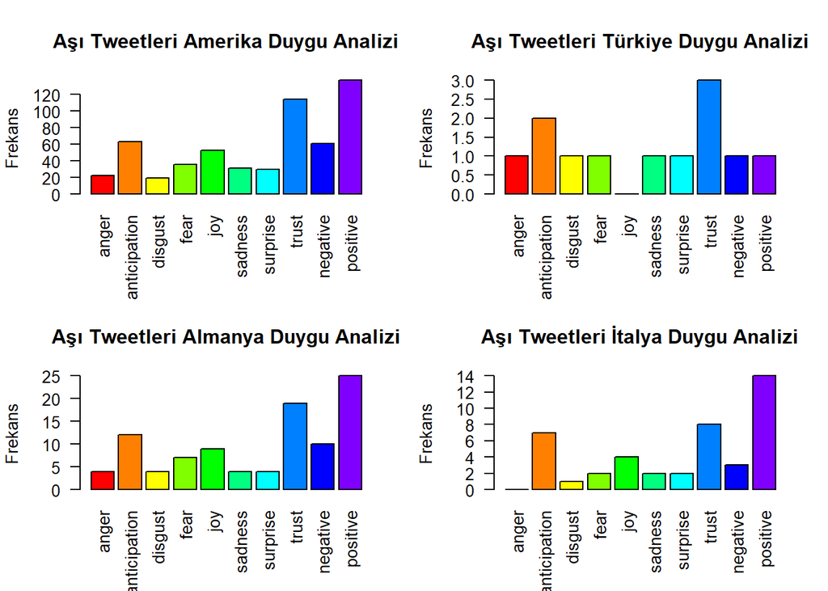

```r
barplot(colSums(ITALY.DA),
        las = 2,
        col = rainbow(12),
        ylab = 'Frekans',
        main = 'Aşı Tweetleri İtalya Duygu Analizi')
```

```r
#par(mfrow=c(2,2)) bir sonraki işlemde karşılaştırma grafiğinin üstüne grafik çizdirilmemesi için baştaki karşılaştırma kodunun tekrar çalıştırılması gerekir.
```

Aşı hakkında atılan tweetleri belirli ülkeler arasında incelediğimizde; Aşı tweetlerinin Amerika,Almanya ve İtalya’daki kullanıcılar üzerinde sıklıkla **pozitif** düşünceleri gördüğümüz gibi, aşının **güven** verdiğini de görmekteyiz. Türkiyede ise aşı tweetlerine baktığımızda aşının sıklıkla kullanıcılara güven verdiği gibi,bu kullanıcıların **beklenti** içerisinde olduğunu da göstermektedir.

## Kaynaklar

https://bookdown.org/content/2096/twitter-ile-metin-madenciligi.html#metin-temizligi

https://www.newslabturkey.org/r-ekosisteminde-metin-madenciligi-nasil-yapilir/

https://tevfikbulut.com/2018/08/02/kelime-bulutu-word-cloud/

https://www.dropbox.com/sh/9uwf4ygv0kwhh0l/AAClYX8WCEPxtQOGP4a3z0e-a/Ders_notlari?dl=0&preview=metinmadenciligi_giris1.Rmd&subfolder_nav_tracking=1

https://rstudio-pubs-static.s3.amazonaws.com/118348_a00ba585d2314b3c937d6acd4f4698b0.html